# Advanced Methods

Timo Meiendresch

4 February 2019

```r
library("astsa")
library("ggplot2")
library("forecast")
library("fpp2")
```

# Advanced methods

## Dynamic Regression

Combine external information with previous observations of the time series. Until now, we only used the time series itself. Now we’ll add external information to describe today’s value of $y_t$. Regression model with ARIMA errors.

$$y_t = \beta_0 + \beta_1 x_{1,t} + ... + \beta_r x_{r,t} + e_t$$

The information on past observations of $y_t$ is included in the error term.

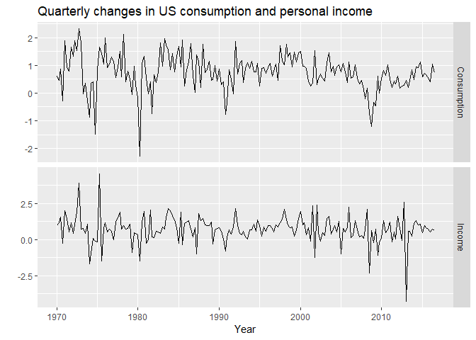

```r
autoplot(uschange[, 1:2], facets =TRUE) +
  xlab("Year") + ylab("") +
  ggtitle("Quarterly changes in US consumption and personal income")
```

It seems as if there is some connection between these two series as one might expect that consumption increases if Income increases and v.v. Use a scatterplot to have a closer look at how these variables are related.

```
## Smoothing formula not specified. Using: y ~ x
```

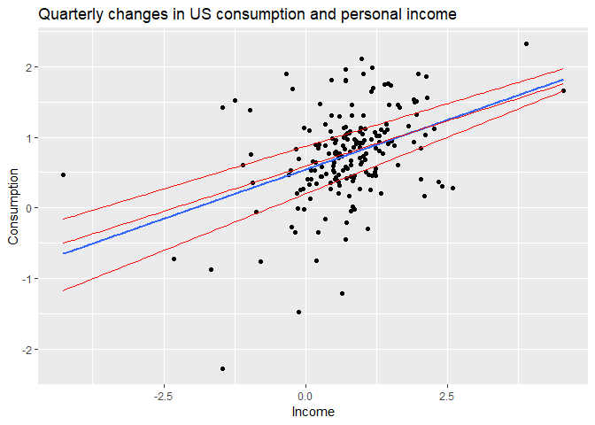

```r
ggplot(aes(x = Income, y=Consumption),
       data=as.data.frame(uschange))+
  geom_point() +
  ggtitle("Quarterly changes in US consumption and personal income") +
  geom_smooth(method=lm, se=FALSE) +
  geom_quantile(col="red", quantiles = c(0.25,0.5,0.75))
```

```r
fit1 <- lm(Consumption ~ Income, data=as.data.frame(uschange))
summary(fit1)
```

```
##
## Call:
## lm(formula = Consumption ~ Income, data = as.data.frame(uschange))
##
## Residuals:
##      Min       1Q   Median       3Q      Max
## -2.40845 -0.31816  0.02558  0.29978  1.45157
##
## Coefficients:
##             Estimate Std. Error t value Pr(>|t|)
## (Intercept)  0.54510    0.05569   9.789  < 2e-16 ***
## Income       0.28060    0.04744   5.915 1.58e-08 ***
## ---
## Signif. codes:  0 '***' 0.001 '**' 0.01 '*' 0.05 '.' 0.1 ' ' 1
##
## Residual standard error: 0.6026 on 185 degrees of freedom
## Multiple R-squared:  0.159,  Adjusted R-squared:  0.1545
## F-statistic: 34.98 on 1 and 185 DF,  p-value: 1.577e-08
```

It seems that there is a considerable relation which can be used to improve our model.

```r
# fit using auto.arima
fit <- auto.arima(uschange[,"Consumption"], xreg = uschange[, "Income"])
fit
```

```
## Series: uschange[, "Consumption"]
## Regression with ARIMA(1,0,2) errors
##
## Coefficients:
##          ar1      ma1     ma2  intercept    xreg
##       0.6922  -0.5758  0.1984     0.5990  0.2028
## s.e.  0.1159   0.1301  0.0756     0.0884  0.0461
##
## sigma^2 estimated as 0.3219:  log likelihood=-156.95
## AIC=325.91   AICc=326.37   BIC=345.29
```

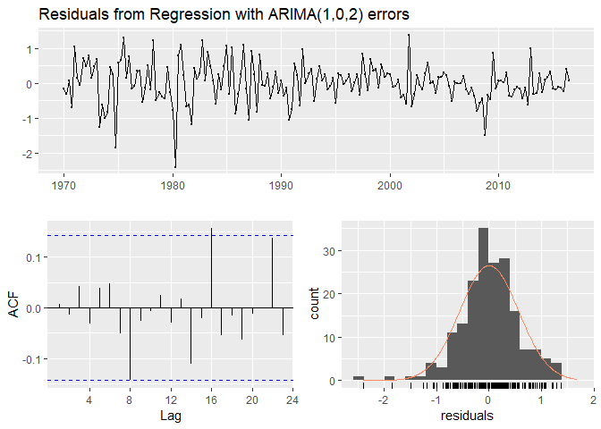

```
##
##  Ljung-Box test
##
## data:  Residuals from Regression with ARIMA(1,0,2) errors
## Q* = 5.8916, df = 3, p-value = 0.117
##
## Model df: 5.   Total lags used: 8
```

```r
checkresiduals(fit)
```

Null hypothesis of white noise cannot be rejected, which means that these residual do look like white noise.

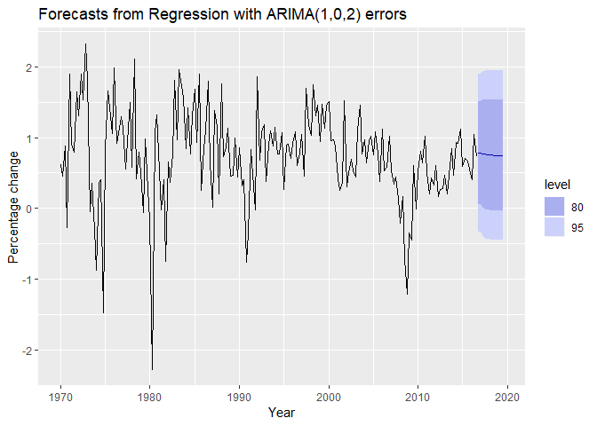

```r
# Forecast a model, assuming Income change is equal to mean for the forecasted values
fcast <- forecast(fit, xreg=rep(mean(uschange[,"Income"]), 12))
autoplot(fcast) +
  xlab("Year") +
  ylab("Percentage change")
```

### Forecasting sales using advertising

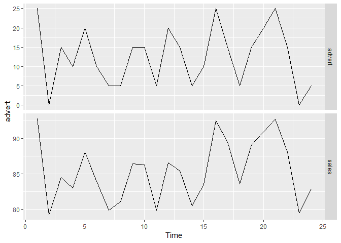

```r
# Time plot of both variables
autoplot(advert, facets=TRUE)
```

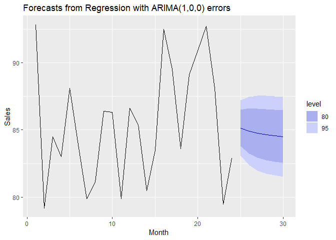

```r
# Fit ARIMA model
fit <- auto.arima(advert[, "sales"], xreg = advert[, "advert"], stationary = TRUE)

# Check model. Increase in sales for each unit increase in advertising
salesincrease <- coefficients(fit)[3]

# Forecast fit as fc
fc <- forecast(fit, xreg = rep(10, 6))

# Plot fc with x and y labels
autoplot(fc) + xlab("Month") + ylab("Sales")
```

### Forecasting electricity demand

```r
# Time plots of demand and temperatures
#autoplot(elec[, c("Demand", "Temperature")], facets = TRUE)

# Matrix of regressors
#xreg <- cbind(MaxTemp = elec[, "Temperature"], MaxTempSq = elec[,"Temperature"]^2, Workday = elec[,"Workday"])

# Fit model
#fit <- auto.arima(elec[,"Demand"], xreg = xreg)

# Forecast fit one day ahead, temp = 20, wday=1
#forecast(fit, xreg = cbind(20, 20^2, 1))
```

### Dynamic harmonic regression

Based on pairs of Fourier terms.

- Every periodic function can be approximated by sums of sin and cos terms for large enough K.
- Regression coefficients: $\alpha_k$ and $\gamma_k$
- $e_t$ can be modeled as a non-seasonal ARIMA process.
- Assumes seasonal pattern does not change over time

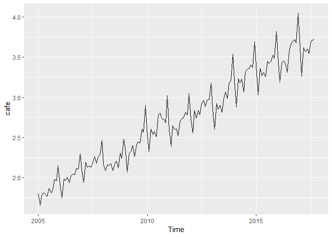

```r
cafe <- window(auscafe, start=2005)
autoplot(cafe)
```

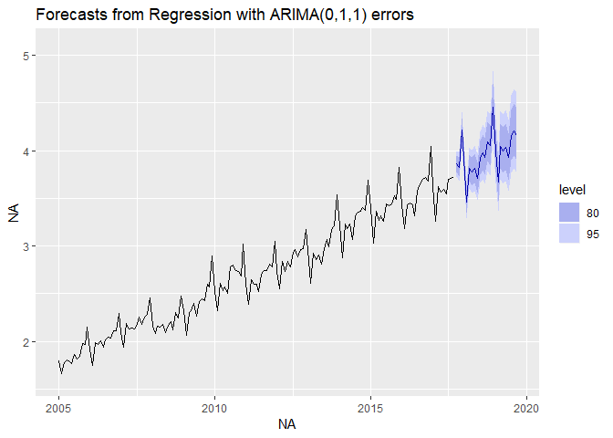

```r
fit <- auto.arima(cafe, xreg = fourier(cafe, K=5),
                  seasonal = FALSE, lambda=0)

fit %>%
  forecast(xreg = fourier(cafe, K=5, h=24)) %>%
  autoplot() + ylim(1.6, 5.1)
```

- Other predictor variables can be added as well: $x_{t,1}, ...., X_{t,r}$
- Choose K to minimize the AICc
- Advantage of Fourier: They can handle seasonality when m (frequency) becomes very large -> weekly, daily, and sub-daily…

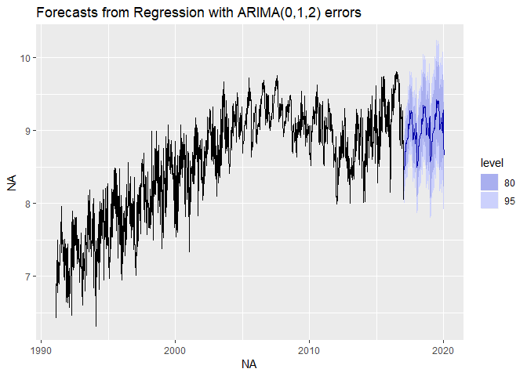

```r
# Set up harmonic regressors of order 13
harmonics <- fourier(gasoline, K = 13)

# Fit regression model with ARIMA errors
# seasonal is false because seasonality is handled by regressors
fit <- auto.arima(gasoline, xreg = harmonics, seasonal = FALSE)

# Forecasts next 3 years
newharmonics <- fourier(gasoline, K = 13, h = 156)
fc <- forecast(fit, xreg = newharmonics)

# Plot forecasts fc
autoplot(fc)
```

#### Forecasting electricity demand

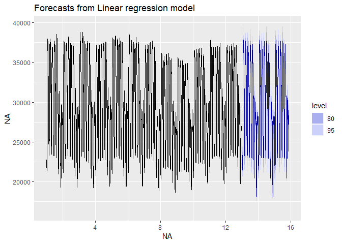

```r
# Fit a harmonic regression using order 10 for each type of seasonality
fit <- tslm(taylor ~ fourier(taylor, K = c(10, 10)))

# Forecast 20 working days ahead
fc <- forecast(fit, newdata = data.frame(fourier(taylor, K = c(10,10), h = 960)))

# Plot the forecasts
autoplot(fc)
```

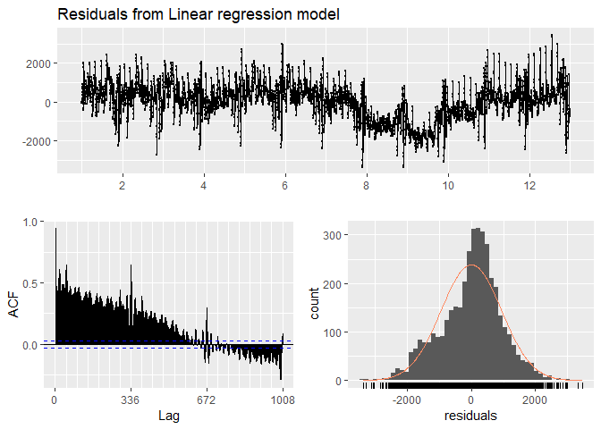

```
##
##  Breusch-Godfrey test for serial correlation of order up to 672
##
## data:  Residuals from Linear regression model
## LM test = 3938.9, df = 672, p-value < 2.2e-16
```

```r
# Check the residuals of fit
checkresiduals(fit)
```

```r
# Residuals fail the tests badly, yet the forecasts are good
```

#### Forecasting call bookings

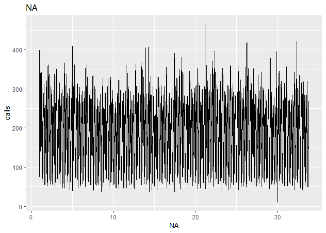

```r
# Plot the calls data
autoplot(calls)
```

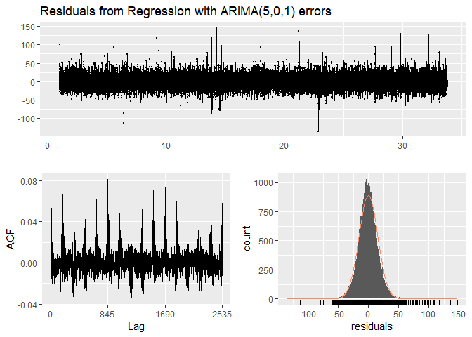

```
##
##  Ljung-Box test
##
## data:  Residuals from Regression with ARIMA(5,0,1) errors
## Q* = 6846.8, df = 1663, p-value < 2.2e-16
##
## Model df: 27.   Total lags used: 1690
```

```r
# Set up the xreg matrix
xreg <- fourier(calls, K = c(10,0))

# Fit a dynamic regression model
fit <- auto.arima(calls, xreg=xreg, seasonal = FALSE, stationary = TRUE)

# Check the residuals
checkresiduals(fit)
```

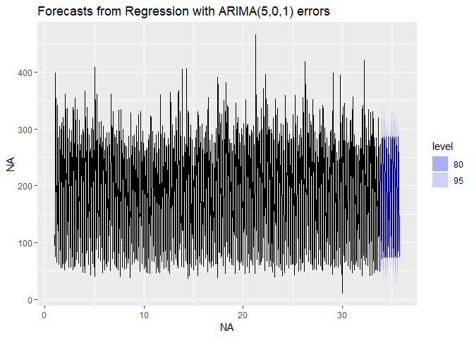

```r
# Plot forecasts for 10 working days ahead
fc <- forecast(fit, xreg =  fourier(calls, c(10, 0), h = 1690))
autoplot(fc)
```

The residuals in this case still fail the white noise tests, but their autocorrelations are tiny, even though they are significant. This is because the series is so long. It is often unrealistic to have residuals that pass the tests for such long series. The effect of the remaining correlations on the forecasts will be negligible.

### TBATS model

Combines many models into one automated framework:

- Trigonometric terms for seasonality
- Box-Cox transformations for heterogeneity
- ARMA models for short-term dynamics
- Trend (possibly damped)
- Seasonal (including multiple and non-integer periods)

Automated framework can be dangerous! Easy to use and it does everything for you:

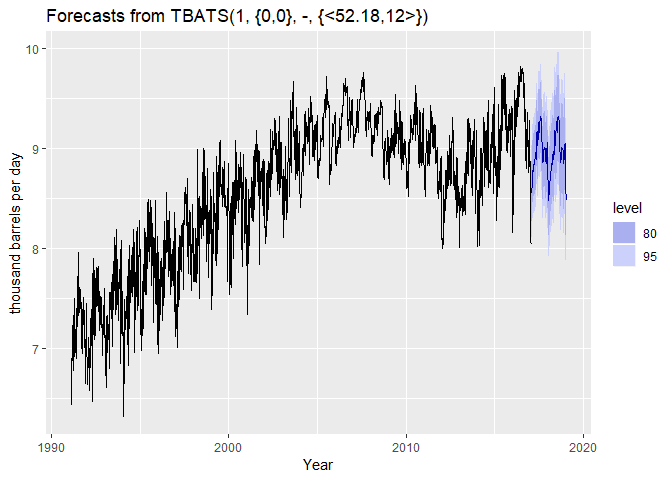

```r
gasoline %>%
  tbats() %>%
  forecast() %>%
  autoplot() + xlab("Year") + ylab("thousand barrels per day")
```

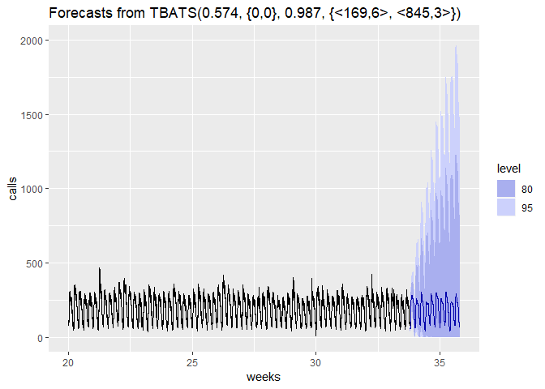

```r
calls %>%
  window(start=20) %>%
  tbats() %>%
  forecast() %>%
  autoplot() + xlab("weeks") + ylab("calls")
```

Here we see that there are two fourier terms as there are two types of seasonality:

Summary TBATS:

- Handles non-integer seasonality, multiple seasonal periods
- Entirely automated
- Predition intervals often too wide
- very slow on long series

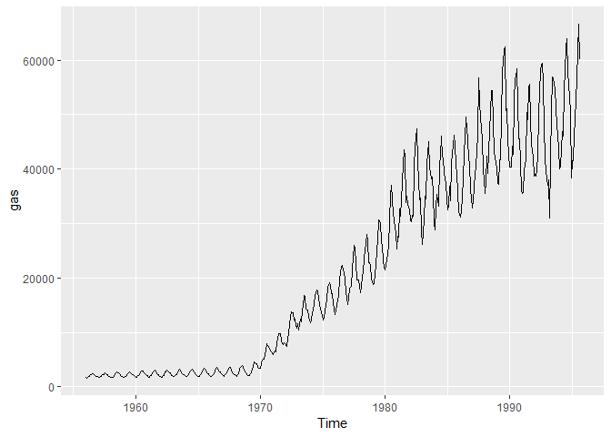

```r
# Plot the gas data
autoplot(gas)
```

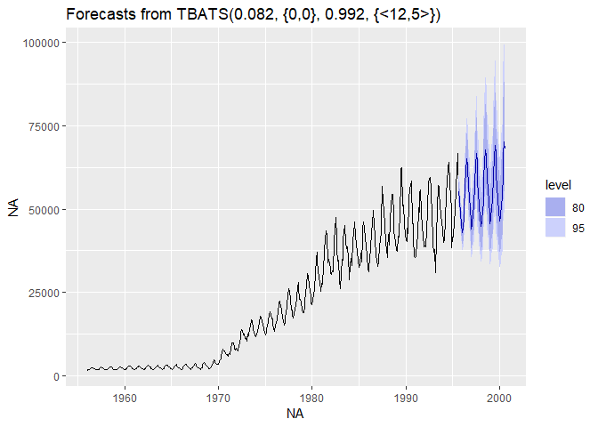

```r
# Fit a TBATS model to the gas data
fit <- tbats(gas)

# Forecast the series for the next 5 years
fc <- forecast(fit, h= 60)

# Plot the forecasts
autoplot(fc)
```

```r
# Record the Box-Cox parameter and the order of the Fourier terms
lambda <- 0.082
K <- 5
```

The gas data contains Australian monthly gas production. A plot of the data shows the variance has changed a lot over time, so it needs a transformation. The seasonality has also changed shape over time, and there is a strong trend. This makes it an ideal series to test the tbats() function which is designed to handle these features.

Note that the book on which this summary was based is online [here](https://otexts.com/fpp2/).